Skip to contents

# Labeling

Source: [`vignettes/labels.Rmd`](https://github.com/strohne/volker/blob/main/vignettes/labels.Rmd)

## The codebook function

Labels used in plots and tables are stored in the comment attribute of the variable. You can inspect all labels using the `codebook()`-function:

```r
codebook(ds)
```

```
#> # A tibble: 97 × 6
#>    item_name     item_group item_class item_label         value_name value_label
#>    <chr>         <chr>      <chr>      <chr>              <chr>      <chr>
#>  1 case          case       numeric    case               NA         NA
#>  2 sd_age        sd         numeric    Age                NA         NA
#>  3 cg_activities cg         character  Activities with C… NA         NA
#>  4 cg_act_write  cg         character  cg_act_write       NA         NA
#>  5 cg_act_test   cg         character  cg_act_test        NA         NA
#>  6 cg_act_search cg         character  cg_act_search      NA         NA
#>  7 adopter       adopter    factor     Innovator type     I try new… I try new …
#>  8 adopter       adopter    factor     Innovator type     I try new… I try new …
#>  9 adopter       adopter    factor     Innovator type     I wait un… I wait unt…
#> 10 adopter       adopter    factor     Innovator type     I only us… I only use…
#> # ℹ 87 more rows
```

To conveniently manage all labels of a dataset, you can save the result of `codebook()` to an Excel file, change the labels manually in a copy of the Excel file, and finally call `labs_apply()` with your revised codebook.

```r
library(readxl)
library(writexl)

# Save codebook to a file
codes <- codebook(ds)
write_xlsx(codes,"codebook.xlsx")

# Load and apply a codebook from a file
codes <- read_xlsx("codebook_revised.xlsx")
ds <- labs_apply(codebook)
```

## Change labels of selected items

You can set specific column labels by providing a named list to the items-parameter of `labs_apply()`:

```r
ds %>%
  labs_apply(
    items = list(
      "cg_adoption_advantage_01" = "Allgemeine Vorteile",
      "cg_adoption_advantage_02" = "Finanzielle Vorteile",
      "cg_adoption_advantage_03" = "Vorteile bei der Arbeit",
      "cg_adoption_advantage_04" = "Macht mehr Spaß"
    )
  ) %>%
  tab_metrics(starts_with("cg_adoption_advantage_"))
```

| Item | min | q1 | median | q3 | max | mean | sd | n |
| --- | --- | --- | --- | --- | --- | --- | --- | --- |
| Allgemeine Vorteile | 1 | 3 | 4 | 4 | 5 | 3.5 | 1.0 | 99 |
| Finanzielle Vorteile | 1 | 2 | 3 | 4 | 5 | 2.7 | 1.2 | 99 |
| Vorteile bei der Arbeit | 1 | 3 | 4 | 4 | 5 | 3.6 | 1.1 | 99 |
| Macht mehr Spaß | 1 | 3 | 4 | 4 | 5 | 3.5 | 1.0 | 99 |

n=99. 2 missing case(s) omitted.

Alternatively, you can use a dataframe in the codebook format. In this case, provide a tibble with item names in the first column and item labels in the second column.

The tribble function is a convenient way to construct the label tibble.

```r
newlabels <- tribble(
  ~item_name, ~item_label,
  "cg_adoption_advantage_01", "Allgemeine Vorteile",
  "cg_adoption_advantage_02", "Finanzielle Vorteile",
  "cg_adoption_advantage_03", "Vorteile bei der Arbeit",
  "cg_adoption_advantage_04", "Macht mehr Spaß"
)

ds %>%
  labs_apply(newlabels) %>%
  tab_metrics(starts_with("cg_adoption_advantage_"))
```

| Item | min | q1 | median | q3 | max | mean | sd | n |
| --- | --- | --- | --- | --- | --- | --- | --- | --- |
| Allgemeine Vorteile | 1 | 3 | 4 | 4 | 5 | 3.5 | 1.0 | 99 |
| Finanzielle Vorteile | 1 | 2 | 3 | 4 | 5 | 2.7 | 1.2 | 99 |
| Vorteile bei der Arbeit | 1 | 3 | 4 | 4 | 5 | 3.6 | 1.1 | 99 |
| Macht mehr Spaß | 1 | 3 | 4 | 4 | 5 | 3.5 | 1.0 | 99 |

n=99. 2 missing case(s) omitted.

## Change labels of values in selected columns

Data values usally come in two forms:

- Uncoded: Character values and factor values as well as metric values such as the age of a person can be analyzed and reported without further labeling. The values in the dataset speak for themselves. Usually you don’t relabel the values, you change them directly in the dataset.
- Coded: Sometimes data values are numerically coded, for example from 1=disagree to 5 =agree. The values need to be labeled for reporting and interpretation.

Labels for both, coded and uncoded values, can be adjusted by providing a named list to the values-parameter of `labs_apply()`. In addition, select the columns where value labels should be changed:

### Coded values example

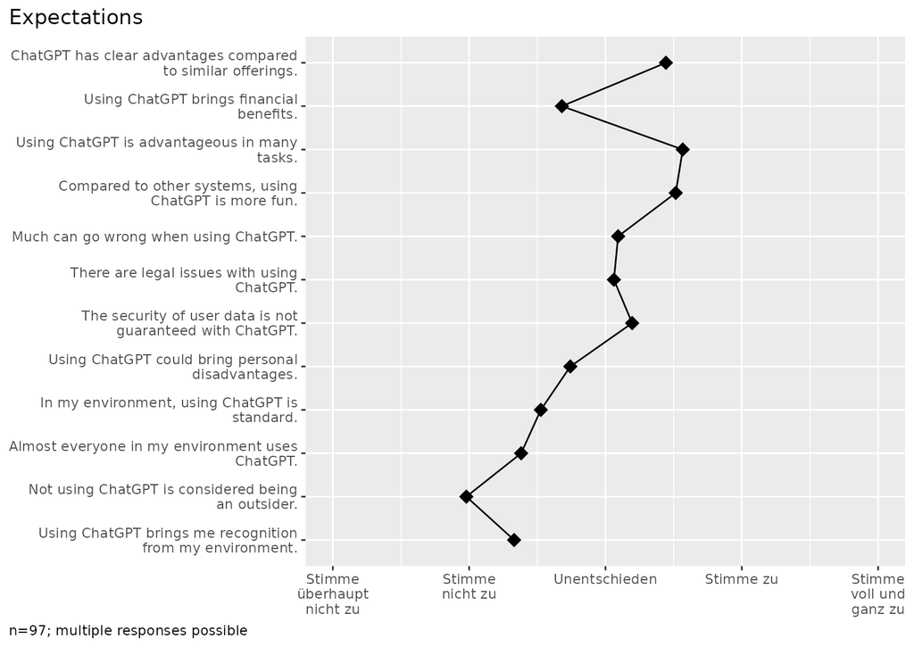

```r
ds %>%
  labs_apply(
    cols=starts_with("cg_adoption"),
    values = list(
      "1" = "Stimme überhaupt nicht zu",
      "2" = "Stimme nicht zu",
      "3" = "Unentschieden",
      "4" = "Stimme zu",
      "5" =  "Stimme voll und ganz zu"
    )
  ) %>%
  plot_metrics(starts_with("cg_adoption"))
```

### Uncoded (factor) values example

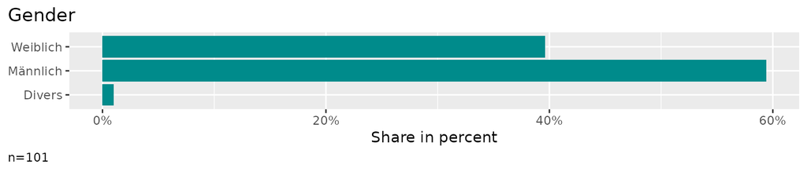

```r
ds %>%
  labs_apply(
    cols=sd_gender,
    values = list(
      "female" = "Weiblich",
      "male" = "Männlich",
      "diverse" = "Divers"
    )
  ) |>
  plot_counts(sd_gender)
```

*Hint*: To see the raw unlabeled values, call plot, tab, or report functions with the labels-parameter set to FALSE, e.g. `plot_counts(ds, starts_with("cg_adoption"), labels = FALSE)`.

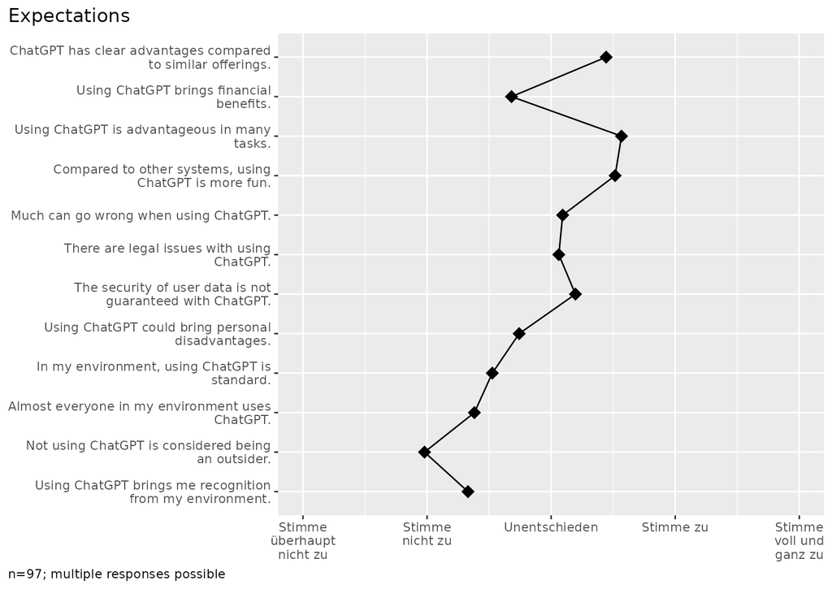

```r
newlabels <-  tribble(
  ~value_name, ~value_label,
  1, "Stimme überhaupt nicht zu",
  2, "Stimme nicht zu",
  3, "Unentschieden",
  4, "Stimme zu",
  5, "Stimme voll und ganz zu"
)

ds |>
  labs_apply(newlabels, cols=starts_with("cg_adoption")) |>
  plot_metrics(starts_with("cg_adoption"))
```

### Clear labels

You can remove all labels with `labs_clear()` to get a plain dataset.

```r
ds %>%
  labs_clear(everything()) %>%
  tab_counts(starts_with("cg_adoption_advantage_"))
```

| cg_adoption_advantage_0 | -9 | 1 | 2 | 3 | 4 | 5 | total |
| --- | --- | --- | --- | --- | --- | --- | --- |
| 1 | 2% (2) | 6% (6) | 8% (8) | 34% (34) | 37% (37) | 14% (14) | 100% (101) |
| 2 | 0% (0) | 22% (22) | 21% (21) | 30% (30) | 22% (22) | 6% (6) | 100% (101) |
| 3 | 0% (0) | 6% (6) | 10% (10) | 21% (21) | 47% (47) | 17% (17) | 100% (101) |
| 4 | 0% (0) | 6% (6) | 4% (4) | 36% (36) | 40% (40) | 15% (15) | 100% (101) |

n=101.

With the labels parameter, you achieve a similar result.

```r
ds %>%
  tab_counts(starts_with("cg_adoption_advantage_"), labels= FALSE)
```

| cg_adoption_advantage_0 | 1 | 2 | 3 | 4 | 5 | total |
| --- | --- | --- | --- | --- | --- | --- |
| 1 | 6% (6) | 8% (8) | 34% (34) | 37% (37) | 14% (14) | 100% (99) |
| 2 | 22% (22) | 21% (21) | 29% (29) | 21% (21) | 6% (6) | 100% (99) |
| 3 | 6% (6) | 10% (10) | 21% (21) | 45% (45) | 17% (17) | 100% (99) |
| 4 | 6% (6) | 4% (4) | 35% (35) | 39% (39) | 15% (15) | 100% (99) |

n=99. 2 missing case(s) omitted.